# EXPLORATORY DATA ANALYSIS COURSE PROJECT

# COURSE CODE-21ECSC210

# TEAM -2

# REPRODUCTIVE AND CHILD HEALTH IN KARNATAKA

# Guided By: Dr. P.G Sunitha Hiremath

### TEAM DETAILS

```python
team_details = {
    'Name': ['Namrata', 'Ananya', 'Kavya','Nirmala'],
    'Roll No': [502,511,526,534],
    'USN': ['01FE21BCS013', '01FE21BCS059', '01FE21BCS131','01FE21BCS180']
}
df = pd.DataFrame(team_details)
df
```

|  | Name | Roll No | USN |
| --- | --- | --- | --- |
| 0 | Namrata | 502 | 01FE21BCS013 |
| 1 | Ananya | 511 | 01FE21BCS059 |
| 2 | Kavya | 526 | 01FE21BCS131 |
| 3 | Nirmala | 534 | 01FE21BCS180 |

```python
#import all libraries
import numpy as np
import pandas as pd
import matplotlib.pyplot as plt
import seaborn as sns
```

```python
import warnings
warnings.filterwarnings('ignore')
```

```python
names=pd.read_csv("D:\\NOTES\\4th SEM\\EDA\\Latest\\Dataset.csv")
names
```

|  | Sl no | Year | District | Total reported deliveries | Total Number of reported live births | Number of Infants given BCG | Number of Infants given DPT1 | Number of Infants given DPT2 | Number of Infants given DPT3 | Number of Infants given Measles | ... | Total Number of Infant Deaths reported | % Deaths due to Sepsis to Total Reported Infant Deaths | % Deaths due to Asphyxia to Total Reported Infant Deaths | % Deaths due to Pneumonia to Total Reported Infant Deaths | % Deaths due to Diarrhoea to Total Reported Infant Deaths | % Deaths due to Fever to Total Reported Infant Deaths | % Deaths due to Measles to Total Reported Infant Deaths | No. of infants received Rotavirus Vaccine 1st dose.1 | No. of infants received Rotavirus Vaccine 2nd dose.1 | No. of infants received Rotavirus Vaccine 3rd dose |
| --- | --- | --- | --- | --- | --- | --- | --- | --- | --- | --- | --- | --- | --- | --- | --- | --- | --- | --- | --- | --- | --- |
| 0 | 1 | 2017-18 | Bagalkote | 41598 | 41549 | 48419 | 0 | 0 | 0 | 565 | ... | 196 | 3.6 | 12.8 | 1.5 | 0.0 | 0.5 | 0.0 | 0 | 0 | 0 |
| 1 | 2 | 2017-18 | Bangalore Rural | 8738 | 8688 | 9238 | 133 | 18 | 30 | 6075 | ... | 25 | 8.0 | 8.0 | 4.0 | 0.0 | 4.0 | 0.0 | 17 | 0 | 0 |
| 2 | 3 | 2017-18 | Bangalore Urban | 106505 | 105568 | 132495 | 890 | 673 | 686 | 9604 | ... | 1366 | 26.3 | 13.8 | 2.5 | 0.4 | 2.1 | 0.1 | 523 | 498 | 497 |
| 3 | 4 | 2017-18 | Belgaum | 76668 | 76212 | 99748 | 501 | 244 | 338 | 8678 | ... | 593 | 8.4 | 15.2 | 4.7 | 0.5 | 1.0 | 0.8 | 26 | 0 | 8 |
| 4 | 5 | 2017-18 | Bellary | 43968 | 43349 | 52463 | 89 | 47 | 90 | 7695 | ... | 481 | 7.3 | 26.4 | 2.7 | 0.0 | 2.1 | 0.0 | 189 | 7 | 6 |
| ... | ... | ... | ... | ... | ... | ... | ... | ... | ... | ... | ... | ... | ... | ... | ... | ... | ... | ... | ... | ... | ... |
| 85 | 86 | 2019-20 | Shimoga | 24725 | 24627 | 23540 | 24 | 8 | 9 | 81 | ... | 491 | 4.9 | 11.4 | 5.1 | 0.2 | 0.8 | 0.0 | 13128 | 10461 | 8605 |
| 86 | 87 | 2019-20 | Tumkur | 29767 | 29684 | 31730 | 8 | 5 | 2 | 24 | ... | 413 | 9.9 | 10.7 | 6.5 | 2.4 | 0.7 | 0.2 | 22068 | 18206 | 16175 |
| 87 | 88 | 2019-20 | Udupi | 13831 | 13809 | 13822 | 42 | 24 | 21 | 178 | ... | 148 | 13.5 | 2.7 | 7.4 | 0.7 | 0.0 | 0.0 | 7628 | 6225 | 5094 |
| 88 | 89 | 2019-20 | Uttara Kannada | 19727 | 19785 | 18898 | 168 | 81 | 68 | 144 | ... | 192 | 2.6 | 5.2 | 9.4 | 0.0 | 0.0 | 0.0 | 10855 | 8474 | 7123 |
| 89 | 90 | 2019-20 | Yadgir | 29466 | 30545 | 39771 | 670 | 294 | 401 | 4066 | ... | 200 | 4.5 | 12.5 | 6.5 | 0.5 | 1.0 | 0.0 | 18378 | 15028 | 13260 |

90 rows × 31 columns

```python
names.size
```

```
2790
```

```python
names.shape
```

```
(90, 31)
```

```python
names.info()
```

```
<class 'pandas.core.frame.DataFrame'>
RangeIndex: 90 entries, 0 to 89
Data columns (total 31 columns):
 #   Column                                                     Non-Null Count  Dtype
---  ------                                                     --------------  -----
 0   Sl no                                                      90 non-null     int64
 1   Year                                                       90 non-null     object
 2   District                                                   90 non-null     object
 3   Total reported deliveries                                  90 non-null     int64
 4   Total Number of reported live births                       90 non-null     int64
 5   Number of Infants given BCG                                90 non-null     int64
 6   Number of Infants given DPT1                               90 non-null     int64
 7   Number of Infants given DPT2                               90 non-null     int64
 8   Number of Infants given DPT3                               90 non-null     int64
 9   Number of Infants given Measles                            90 non-null     int64
```

[output cut: 23 more lines]

## Data Analysis

### Q1.What is the total number of Reported Deliveries in Karnataka over 3 years?

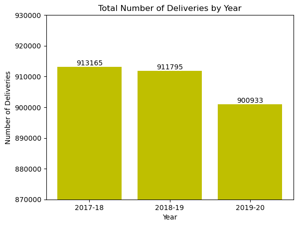

```python
#Total Number of reporated delivaries
sums = names.groupby('Year')['Total reported deliveries'].sum()
years = list(sums.keys())
# Plotting the bar graph
bars = plt.bar(years, sums,color='y')

# Adding labels and title
plt.xlabel('Year')
plt.ylabel('Number of Deliveries')
plt.title('Total Number of Deliveries by Year')

# Set the y-axis limits
plt.ylim([870000, 930000])

# Display the values on top of each bar
for bar in bars:
    height = bar.get_height()
    plt.text(bar.get_x() + bar.get_width() / 2, height, str(height),
             ha='center', va='bottom')

# Display the graph
plt.show()
```

## Inference:

#### This graph shows the total number of Reported deliveries year by year.

-In 2017-18 , highest reported Deliveries are there as compared to 2018-19 and 2019-20.

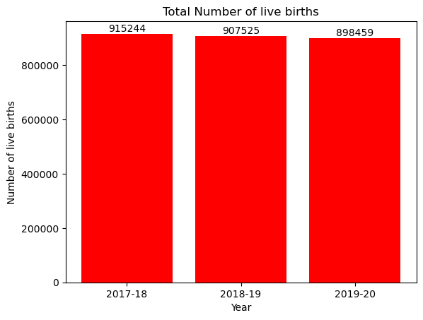

```python
#Number of reported live births
sums = names.groupby('Year')['Total Number of reported live births'].sum()
years = list(sums.keys())
# Plotting the bar graph
bars = plt.bar(years, sums,color='r')

# Adding labels and title
plt.xlabel('Year')
plt.ylabel('Number of live births')
plt.title('Total Number of live births')

# Set the y-axis limits
#plt.ylim([870000, 930000])

# Display the values on top of each bar
for bar in bars:
    height = bar.get_height()
    plt.text(bar.get_x() + bar.get_width() / 2, height, str(height),
             ha='center', va='bottom')

# Display the graph
plt.show()
```

### Inference:

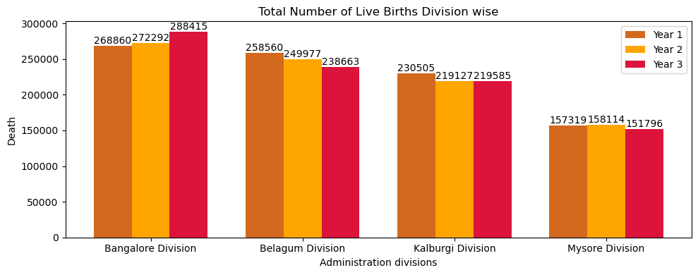

```python
import matplotlib.pyplot as plt

labels = ["Bangalore Division", "Belagum Division", "Kalburgi Division", "Mysore Division"]
year_1 = [268860,258560,230505,157319]
year_2 = [272292,249977,219127,158114]  # Replace these values with data for the second year
year_3 = [288415,238663,219585,151796]  # Replace these values with data for the third year

bar_width = 0.25  # Width of each bar
bar_positions_1 = list(range(len(labels)))
bar_positions_2 = [pos + bar_width for pos in bar_positions_1]
bar_positions_3 = [pos + bar_width * 2 for pos in bar_positions_1]

# Horizontal bar chart with custom colors
plt.figure(figsize=(10, 4))
bars1 = plt.bar(bar_positions_1, year_1, width=bar_width, color="chocolate", label='Year 1')
bars2 = plt.bar(bar_positions_2, year_2, width=bar_width, color="orange", label='Year 2')
bars3 = plt.bar(bar_positions_3, year_3, width=bar_width, color="crimson", label='Year 3')

# Title and labels
plt.title('Total Number of Live Births Division wise')
plt.xlabel('Administration divisions')
plt.ylabel('Death')

# Display the values on top of each bar for year 1
for i, bar in enumerate(bars1):
    plt.text(bar.get_x() + bar.get_width() / 2, bar.get_height(),
             year_1[i], ha='center', va='bottom')

# Display the values on top of each bar for year 2
for i, bar in enumerate(bars2):
    plt.text(bar.get_x() + bar.get_width() / 2, bar.get_height(),
             year_2[i], ha='center', va='bottom')

# Display the values on top of each bar for year 3
for i, bar in enumerate(bars3):
    plt.text(bar.get_x() + bar.get_width() / 2, bar.get_height(),
             year_3[i], ha='center', va='bottom')

# Set the x-axis ticks and labels
plt.xticks([pos + bar_width for pos in bar_positions_1], labels)

# Add a legend
plt.legend()

# Display the chart
plt.tight_layout()
plt.show()
```

## Q3.What is the total number of live births district-wise?

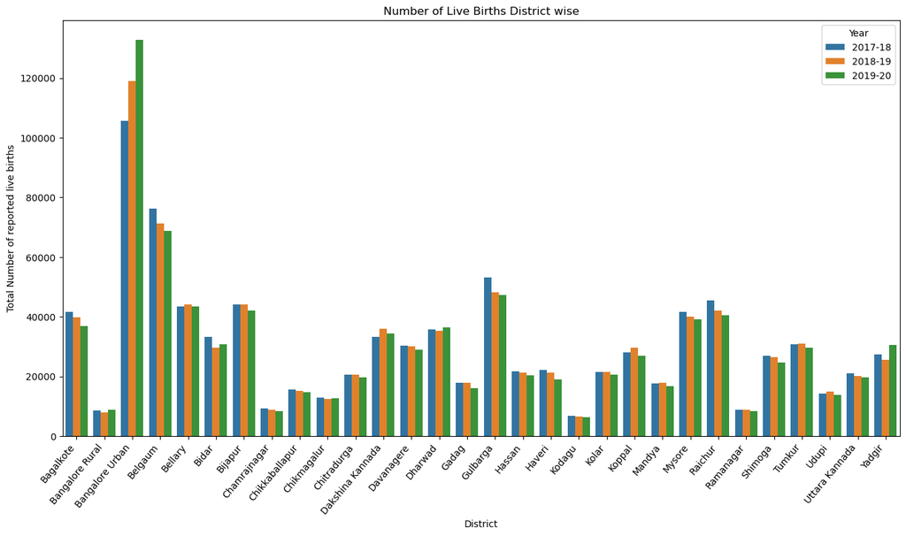

```python
fig, ax=plt.subplots(figsize=(16,8))
sns.barplot(data=names, x="District", y="Total Number of reported live births", hue = 'Year',ax=ax)
ax.set_xticklabels(ax.get_xticklabels(),rotation=50,horizontalalignment='right')
plt.title("Number of Live Births District wise")
plt.show()
```

### Inference:

-In 2017-18, Bangalore Urban has recorded highest number of live births and Kodagu the least.

-In 2018-19, Bangalore Urban has recorded highest number of live births and Kodagu the least.

-In 2019-20, Bangalore Urban has recorded highest number of live births and Kodagu the least.

-Overall population of the Bangalore Urban is more as compared to other district so it will be the one reason for increasing the number of live births in Bangalore Urban year to year.

### Q4.What is the total number of Infant Deaths reported in Karnataka over 3 years?

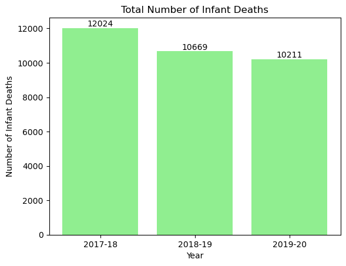

```python
#Number of reported live births
sums = names.groupby('Year')['Total Number of Infant Deaths reported'].sum()
years = list(sums.keys())
# Plotting the bar graph
bars = plt.bar(years, sums,color='lightgreen')

# Adding labels and title
plt.xlabel('Year')
plt.ylabel('Number of Infant Deaths')
plt.title('Total Number of Infant Deaths')

# Set the y-axis limits
#plt.ylim([870000, 930000])

# Display the values on top of each bar
for bar in bars:
    height = bar.get_height()
    plt.text(bar.get_x() + bar.get_width() / 2, height, str(height),
             ha='center', va='bottom')

# Display the graph
plt.show()
```

## Inference:

### In 2017-18 , highest reported Infant deaths as compared to 2018-19 and 2019-20.

### Reasons for this is

-Nutrition level

-Health Facilities

In 2017-18 13 infants are died per 1000 live births

In 2018-19 12 infants are died per 1000 live births

In 2019-20 11 infants are died per 1000 live births

## Number of Infant Death reported in Administrative Divisions of Karnataka

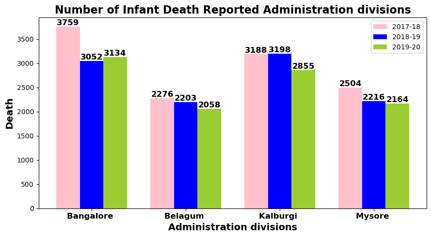

```python
import matplotlib.pyplot as plt

labels = ["Bangalore ", "Belagum ", "Kalburgi ", "Mysore "]
year_1 = [3759, 2276, 3188, 2504]
year_2 = [3052, 2203, 3198, 2216]  # Replace these values with data for the second year
year_3 = [3134, 2058, 2855, 2164]  # Replace these values with data for the third year

bar_width = 0.25  # Width of each bar
bar_positions_1 = list(range(len(labels)))
bar_positions_2 = [pos + bar_width for pos in bar_positions_1]
bar_positions_3 = [pos + bar_width * 2 for pos in bar_positions_1]

# Horizontal bar chart with custom colors
plt.figure(figsize=(9, 5))  # Increase the figure size to make the text more visible
bars1 = plt.bar(bar_positions_1, year_1, width=bar_width, color="pink", label='2017-18')
bars2 = plt.bar(bar_positions_2, year_2, width=bar_width, color="blue", label='2018-19')
bars3 = plt.bar(bar_positions_3, year_3, width=bar_width, color="yellowgreen", label='2019-20')

# Title and labels with increased font size and bold text
plt.title('Number of Infant Death Reported Administration divisions', fontsize=16, fontweight='bold')
plt.xlabel('Administration divisions', fontsize=14, fontweight='bold')
plt.ylabel('Death', fontsize=14, fontweight='bold')

# Display the values on top of each bar for year 1
for i, bar in enumerate(bars1):
    plt.text(bar.get_x() + bar.get_width() / 2, bar.get_height(),
             year_1[i], ha='center', va='bottom', fontsize=12, fontweight='bold', color='black')

# Display the values on top of each bar for year 2
for i, bar in enumerate(bars2):
    plt.text(bar.get_x() + bar.get_width() / 2, bar.get_height(),
             year_2[i], ha='center', va='bottom', fontsize=12, fontweight='bold', color='black')

# Display the values on top of each bar for year 3
for i, bar in enumerate(bars3):
    plt.text(bar.get_x() + bar.get_width() / 2, bar.get_height(),
             year_3[i], ha='center', va='bottom', fontsize=12, fontweight='bold', color='black')

# Set the x-axis ticks and labels
plt.xticks([pos + bar_width for pos in bar_positions_1], labels, fontsize=12, fontweight='bold')

# Add a legend
plt.legend()

# Display the chart
plt.tight_layout()
plt.show()
```

### Overpopulation will be one of the reasons for having the highest infant mortality rate in Bangalore Urban.

## %of infant death

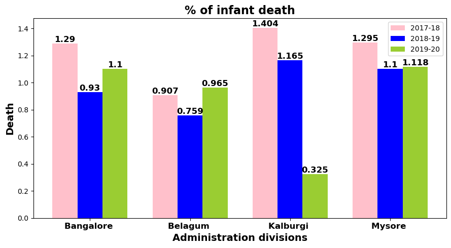

```python
import matplotlib.pyplot as plt

labels = ["Bangalore ", "Belagum ", "Kalburgi ", "Mysore "]
year_1 = [1.29,0.907,1.404,1.295]
year_2 = [0.93,0.759,1.165,1.1]  # Replace these values with data for the second year
year_3 = [1.1,0.965,0.325,1.118]  # Replace these values with data for the third year

bar_width = 0.25  # Width of each bar
bar_positions_1 = list(range(len(labels)))
bar_positions_2 = [pos + bar_width for pos in bar_positions_1]
bar_positions_3 = [pos + bar_width * 2 for pos in bar_positions_1]

# Horizontal bar chart with custom colors
plt.figure(figsize=(9, 5))  # Increase the figure size to make the text more visible
bars1 = plt.bar(bar_positions_1, year_1, width=bar_width, color="pink", label='2017-18')
bars2 = plt.bar(bar_positions_2, year_2, width=bar_width, color="blue", label='2018-19')
bars3 = plt.bar(bar_positions_3, year_3, width=bar_width, color="yellowgreen", label='2019-20')

# Title and labels with increased font size and bold text
plt.title('% of infant death', fontsize=16, fontweight='bold')
plt.xlabel('Administration divisions', fontsize=14, fontweight='bold')
plt.ylabel('Death', fontsize=14, fontweight='bold')

# Display the values on top of each bar for year 1
for i, bar in enumerate(bars1):
    plt.text(bar.get_x() + bar.get_width() / 2, bar.get_height(),
             year_1[i], ha='center', va='bottom', fontsize=12, fontweight='bold', color='black')

# Display the values on top of each bar for year 2
for i, bar in enumerate(bars2):
    plt.text(bar.get_x() + bar.get_width() / 2, bar.get_height(),
             year_2[i], ha='center', va='bottom', fontsize=12, fontweight='bold', color='black')

# Display the values on top of each bar for year 3
for i, bar in enumerate(bars3):
    plt.text(bar.get_x() + bar.get_width() / 2, bar.get_height(),
             year_3[i], ha='center', va='bottom', fontsize=12, fontweight='bold', color='black')

# Set the x-axis ticks and labels
plt.xticks([pos + bar_width for pos in bar_positions_1], labels, fontsize=12, fontweight='bold')

# Add a legend
plt.legend()

# Display the chart
plt.tight_layout()
plt.show()
```

## Q5.How does number of Infant death reported vary across different districts of Karnataka?

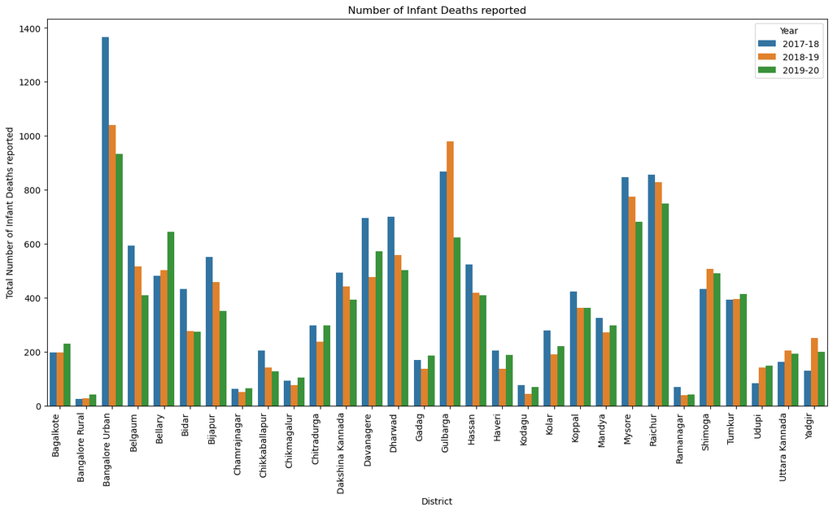

```python
fig, ax=plt.subplots(figsize=(16,8))
sns.barplot(data=names, x="District", y="Total Number of Infant Deaths reported", hue = 'Year',ax=ax)
ax.set_xticklabels(ax.get_xticklabels(),rotation=90,horizontalalignment='right')
plt.title("Number of Infant Deaths reported")
plt.show()
```

## Inference:

-In 2017-18, Bangalore Urban has recorded highest number of infant death and Bangalore Rural the least.

-In 2018-19, Bangalore Urban has recorded highest number of infant death and Bangalore Rural the least.

-In 2019-20, Bangalore Urban has recorded highest number of infant death and Ramanagar the least.

## Q6.What are the leading causes for infant mortality?

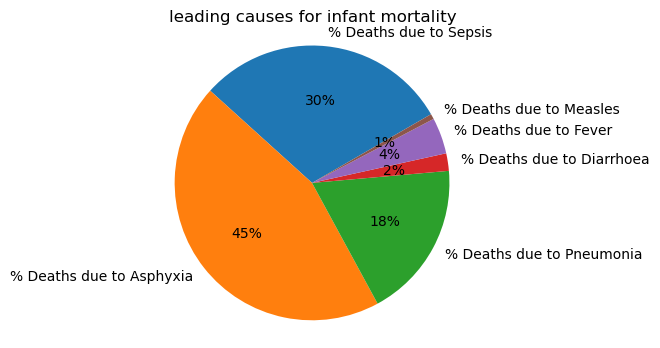

```python
import matplotlib.pyplot as plt

labels = ["% Deaths due to Sepsis", "% Deaths due to Asphyxia", "% Deaths due to Pneumonia",
          "% Deaths due to Diarrhoea", "% Deaths due to Fever", "% Deaths due to Measles"]
sizes = [8.25, 12.29, 5.09, 0.567, 1.172, 0.17]

plt.figure(figsize=(5, 4))
plt.pie(sizes, labels=labels, autopct='%1.0f%%', startangle=30)
plt.title("leading causes for infant mortality")
plt.axis("equal")
plt.show()
```

## Inference:

-This graph depicts the causes of infant death in Karnataka.

-The %death is highest due to Asphyxia and the least is due to Measles.

## Q7.In 2017-18, Which cause of infant death has contributed the highest?

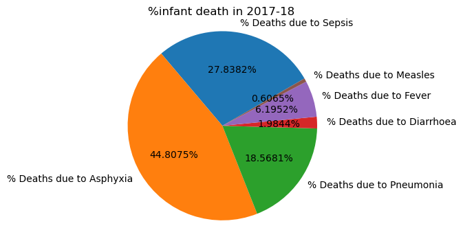

```python
import matplotlib.pyplot as plt

labels = ["% Deaths due to Sepsis", "% Deaths due to Asphyxia", "% Deaths due to Pneumonia",
          "% Deaths due to Diarrhoea", "% Deaths due to Fever", "% Deaths due to Measles"]
sizes = [7.94,12.78,5.296,0.566,1.767,0.173]

plt.figure(figsize=(5, 4))
plt.pie(sizes, labels=labels, autopct='%1.4f%%', startangle=30)
plt.title("%infant death in 2017-18")
plt.axis("equal")
plt.show()
```

## Q8.In 2018-19, Which cause of infant death has contributed the highest?

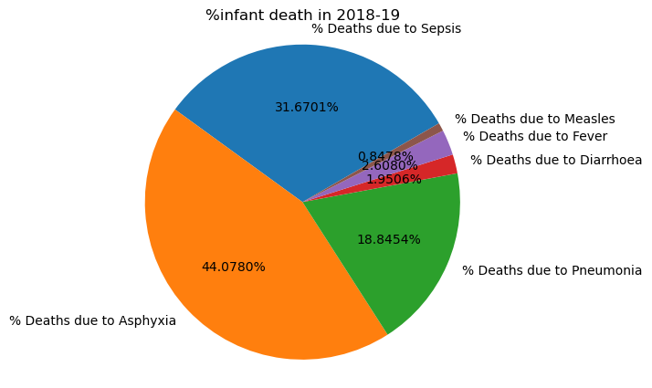

```python
import matplotlib.pyplot as plt

labels = ["% Deaths due to Sepsis", "% Deaths due to Asphyxia", "% Deaths due to Pneumonia",
          "% Deaths due to Diarrhoea", "% Deaths due to Fever", "% Deaths due to Measles"]
sizes = [8.816,12.27,5.246,0.543,0.726,0.236]    #(157.4/30)

plt.figure(figsize=(6, 5))
plt.pie(sizes, labels=labels, autopct='%1.4f%%', startangle=30)
plt.title("%infant death in 2018-19")
plt.axis("equal")
plt.show()
```

## Q9.In 2019-20, Which cause of infant death has contributed the highest?

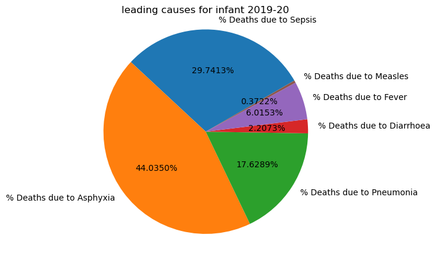

```python
import matplotlib.pyplot as plt

labels = ["% Deaths due to Sepsis", "% Deaths due to Asphyxia", "% Deaths due to Pneumonia",
          "% Deaths due to Diarrhoea", "% Deaths due to Fever", "% Deaths due to Measles"]
sizes = [7.99,11.83,4.736,0.593,1.616,0.1]    #(157.4/30)

plt.figure(figsize=(6, 5))
plt.pie(sizes, labels=labels, autopct='%1.4f%%', startangle=30)
plt.title("leading causes for infant 2019-20")
plt.axis("equal")
plt.show()
```

## Inference:

#### The %death is highest due to Asphyxia and the least is due to Measles.

## Q10.What is the total number of Infants affected due to Sepsis?

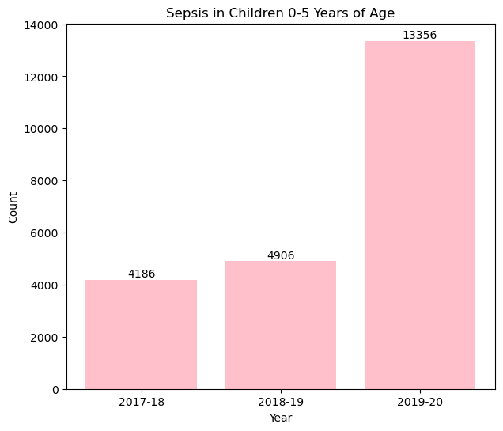

```python
import matplotlib.pyplot as plt

labels = ["2017-18", "2018-19", "2019-20"]
sizes = [4186, 4906, 13356]

# Horizontal bar chart with custom colors
plt.figure(figsize=(7, 6))
bars = plt.bar(labels, sizes,color='pink')

# Title and labels
plt.title('Sepsis in Children 0-5 Years of Age')
plt.xlabel('Year')
plt.ylabel('Count')

# Display the values on top of each bar
for i, bar in enumerate(bars):
    plt.text(bar.get_x() + bar.get_width() / 2, bar.get_height(),
             sizes[i], ha='center', va='bottom')

# Display the chart
plt.show()
```

### Inference:

-This graph gives the number of infants infected due to Sepsis across all districts of Karnataka.

-It depicts that the number of infants affected by sepsis has been increasing Year to year.

## Q11.What is the number of Deaths due to Sepsis?

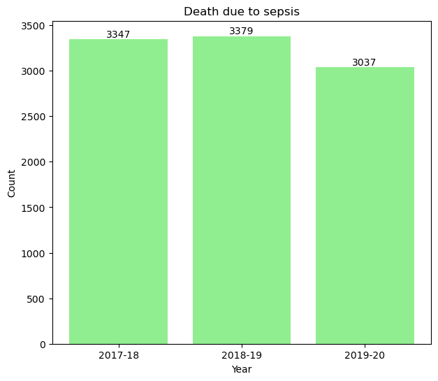

```python
import matplotlib.pyplot as plt

labels = ["2017-18", "2018-19", "2019-20"]
sizes = [3347,3379,3037]

# Horizontal bar chart with custom colors
plt.figure(figsize=(7, 6))
bars = plt.bar(labels, sizes,color='lightgreen')

# Title and labels
plt.title('Death due to sepsis')
plt.xlabel('Year')
plt.ylabel('Count')

# Display the values on top of each bar
for i, bar in enumerate(bars):
    plt.text(bar.get_x() + bar.get_width() / 2, bar.get_height(),
             sizes[i], ha='center', va='bottom')

# Display the chart
plt.show()
```

### Inference:

-This graph gives the number of infant death caused due to Sepsis across all districts of Karnataka.

-It depicts that the number of infants death due to sepsis has been varying Year to year

## Q12.What is the total number of Infants Recovered from Sepsis?

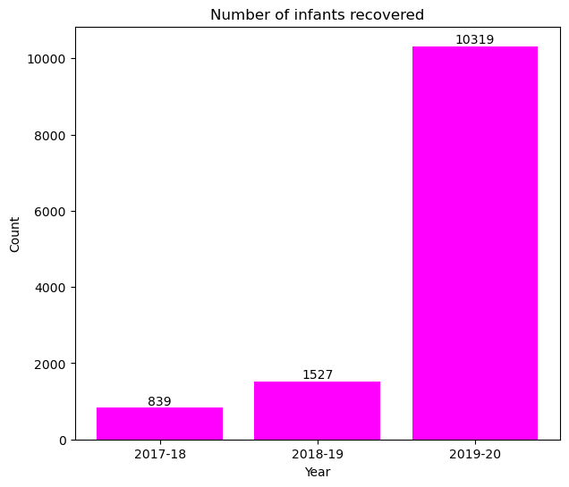

```python
import matplotlib.pyplot as plt

labels = ["2017-18", "2018-19", "2019-20"]
sizes = [839,1527,10319]

# Horizontal bar chart with custom colors
plt.figure(figsize=(7, 6))
bars = plt.bar(labels, sizes,color='magenta')

# Title and labels
plt.title('Number of infants recovered')
plt.xlabel('Year')
plt.ylabel('Count')

# Display the values on top of each bar
for i, bar in enumerate(bars):
    plt.text(bar.get_x() + bar.get_width() / 2, bar.get_height(),
             sizes[i], ha='center', va='bottom')

# Display the chart
plt.show()
```

### Inference

-As compared to 2017-18 and 2018-19 number of infants recovered from sepsis are more because number of infants affected in 2019-20 are more and death occur due to sepsis is also less.

### %death due to Sepsis Division-wise

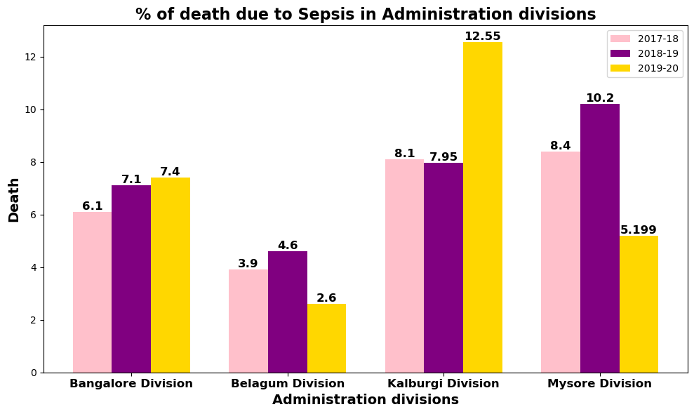

```python
import matplotlib.pyplot as plt

labels = ["Bangalore Division", "Belagum Division", "Kalburgi Division", "Mysore Division"]
year_1 = [6.1,3.9,8.1,8.4]
year_2 = [7.1,4.6,7.95,10.2]  # Replace these values with data for the second year
year_3 = [7.4,2.6,12.55,5.199] # Replace these values with data for the third year

bar_width = 0.25  # Width of each bar
bar_positions_1 = list(range(len(labels)))
bar_positions_2 = [pos + bar_width for pos in bar_positions_1]
bar_positions_3 = [pos + bar_width * 2 for pos in bar_positions_1]

# Horizontal bar chart with custom colors
plt.figure(figsize=(10, 6))  # Increase the figure size to make the text more visible
bars1 = plt.bar(bar_positions_1, year_1, width=bar_width, color="pink", label='2017-18')
bars2 = plt.bar(bar_positions_2, year_2, width=bar_width, color="purple", label='2018-19')
bars3 = plt.bar(bar_positions_3, year_3, width=bar_width, color="gold", label='2019-20')

# Title and labels with increased font size and bold text
plt.title('% of death due to Sepsis in Administration divisions', fontsize=16, fontweight='bold')
plt.xlabel('Administration divisions', fontsize=14, fontweight='bold')
plt.ylabel('Death', fontsize=14, fontweight='bold')

# Display the values on top of each bar for year 1
for i, bar in enumerate(bars1):
    plt.text(bar.get_x() + bar.get_width() / 2, bar.get_height(),
             year_1[i], ha='center', va='bottom', fontsize=12, fontweight='bold', color='black')

# Display the values on top of each bar for year 2
for i, bar in enumerate(bars2):
    plt.text(bar.get_x() + bar.get_width() / 2, bar.get_height(),
             year_2[i], ha='center', va='bottom', fontsize=12, fontweight='bold', color='black')

# Display the values on top of each bar for year 3
for i, bar in enumerate(bars3):
    plt.text(bar.get_x() + bar.get_width() / 2, bar.get_height(),
             year_3[i], ha='center', va='bottom', fontsize=12, fontweight='bold', color='black')

# Set the x-axis ticks and labels
plt.xticks([pos + bar_width for pos in bar_positions_1], labels, fontsize=12, fontweight='bold')

# Add a legend
plt.legend()

# Display the chart
plt.tight_layout()
plt.show()
```

## Q13.What is the % of Death caused due to Sepsis District-wise?

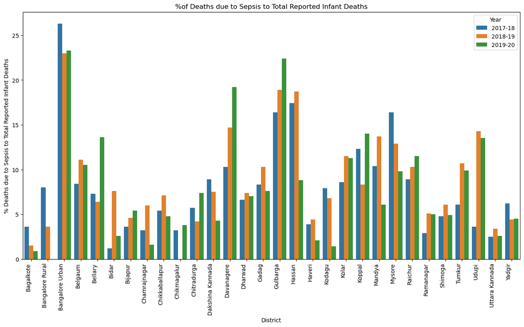

```python
fig, ax=plt.subplots(figsize=(16,8))
sns.barplot(data=names, x="District", y="% Deaths due to Sepsis to Total Reported Infant Deaths", hue = 'Year',ax=ax)
ax.set_xticklabels(ax.get_xticklabels(),rotation=90,horizontalalignment='right')
plt.title("%of Deaths due to Sepsis to Total Reported Infant Deaths")
plt.show()
```

### Inference:

-In 2017-18, Bangalore Urban has recorded highest %of infant death due to Sepsis and Bidar the least.

## Q14.What is the number of death caused due to Asphyxia?

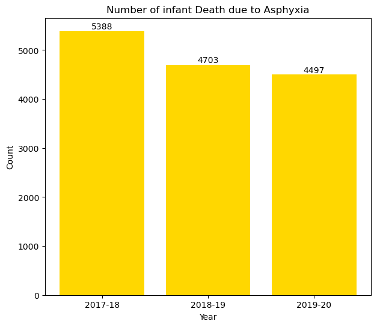

```python
import matplotlib.pyplot as plt

labels = ["2017-18", "2018-19", "2019-20"]
sizes = [5388,4703,4497]

# Horizontal bar chart with custom colors
plt.figure(figsize=(7, 6))
bars = plt.bar(labels, sizes,color='gold')

# Title and labels
plt.title('Number of infant Death due to Asphyxia')
plt.xlabel('Year')
plt.ylabel('Count')

# Display the values on top of each bar
for i, bar in enumerate(bars):
    plt.text(bar.get_x() + bar.get_width() / 2, bar.get_height(),
             sizes[i], ha='center', va='bottom')

# Display the chart
plt.show()
```

### Inference:

This graph gives the number of infant death caused due to Asphyxia across all districts of Karnataka.

-In 2017-18, the death due to Asphyxia was recorded the highest.

### %death due to Asphyxia Division-wise

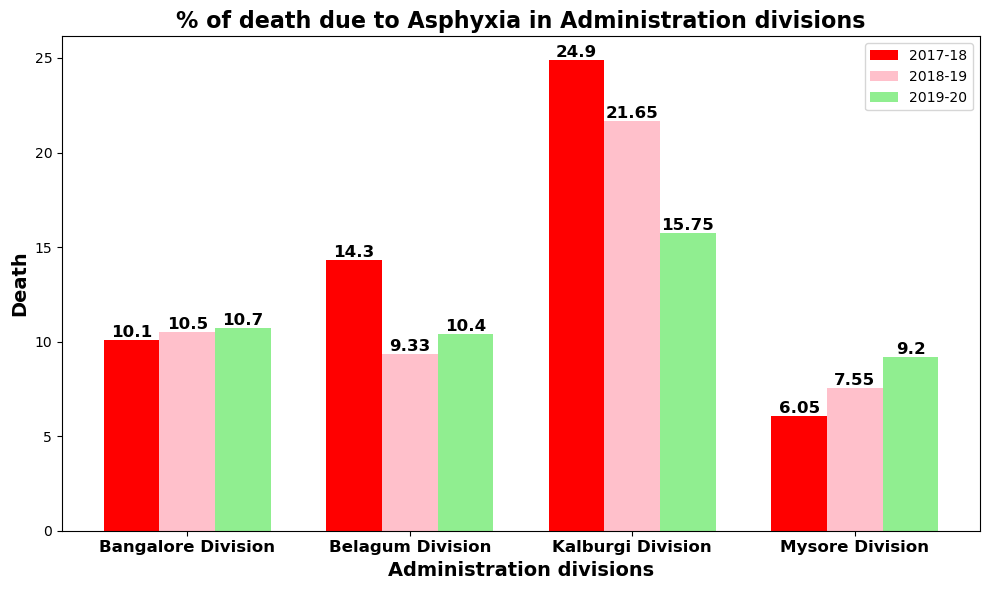

```python
import matplotlib.pyplot as plt

labels = ["Bangalore Division", "Belagum Division", "Kalburgi Division", "Mysore Division"]
year_1 = [10.1,14.3,24.9,6.05]
year_2 = [10.5,9.33,21.65,7.55]  # Replace these values with data for the second year
year_3 = [10.7,10.4,15.75,9.2]   # Replace these values with data for the third year

bar_width = 0.25  # Width of each bar
bar_positions_1 = list(range(len(labels)))
bar_positions_2 = [pos + bar_width for pos in bar_positions_1]
bar_positions_3 = [pos + bar_width * 2 for pos in bar_positions_1]

# Horizontal bar chart with custom colors
plt.figure(figsize=(10, 6))  # Increase the figure size to make the text more visible
bars1 = plt.bar(bar_positions_1, year_1, width=bar_width, color="red", label='2017-18')
bars2 = plt.bar(bar_positions_2, year_2, width=bar_width, color="pink", label='2018-19')
bars3 = plt.bar(bar_positions_3, year_3, width=bar_width, color="lightgreen", label='2019-20')

# Title and labels with increased font size and bold text
plt.title('% of death due to Asphyxia in Administration divisions', fontsize=16, fontweight='bold')
plt.xlabel('Administration divisions', fontsize=14, fontweight='bold')
plt.ylabel('Death', fontsize=14, fontweight='bold')

# Display the values on top of each bar for year 1
for i, bar in enumerate(bars1):
    plt.text(bar.get_x() + bar.get_width() / 2, bar.get_height(),
             year_1[i], ha='center', va='bottom', fontsize=12, fontweight='bold', color='black')

# Display the values on top of each bar for year 2
for i, bar in enumerate(bars2):
    plt.text(bar.get_x() + bar.get_width() / 2, bar.get_height(),
             year_2[i], ha='center', va='bottom', fontsize=12, fontweight='bold', color='black')

# Display the values on top of each bar for year 3
for i, bar in enumerate(bars3):
    plt.text(bar.get_x() + bar.get_width() / 2, bar.get_height(),
             year_3[i], ha='center', va='bottom', fontsize=12, fontweight='bold', color='black')

# Set the x-axis ticks and labels
plt.xticks([pos + bar_width for pos in bar_positions_1], labels, fontsize=12, fontweight='bold')

# Add a legend
plt.legend()

# Display the chart
plt.tight_layout()
plt.show()
```

## Q15.What is the % of Death caused due to Asphyxia (District-wise)?

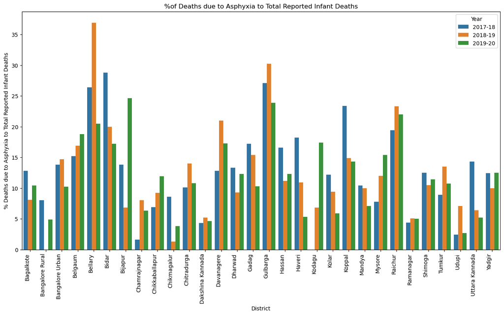

```python
fig, ax=plt.subplots(figsize=(16,8))
sns.barplot(data=names, x="District", y="% Deaths due to Asphyxia to Total Reported Infant Deaths", hue = 'Year',ax=ax)
ax.set_xticklabels(ax.get_xticklabels(),rotation=90,horizontalalignment='right')
plt.title("%of Deaths due to Asphyxia to Total Reported Infant Deaths")
plt.show()
```

### Inference:

-In 2017-18, Bidar has recorded highest %of infant death due to Asphyxia and Kodagu the least.

-In 2018-19, Bellary has recorded highest %of infant death due to Asphyxia and Bangalore Rural the least.

-In 2019-20, Bijapur has recorded highest %of infant death due to Asphyxia and Udupi the least.

## Q16.What is the total number of Infants affected due to Pneumonia?

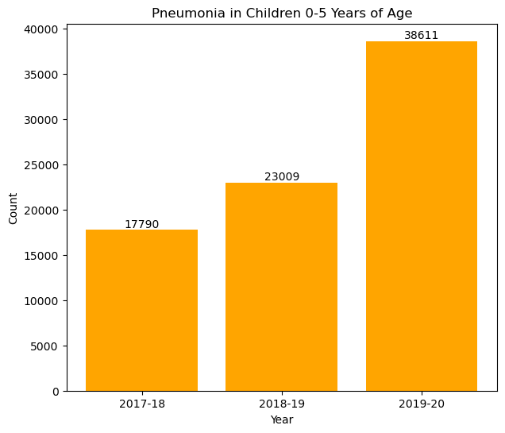

```python
import matplotlib.pyplot as plt

labels = ["2017-18", "2018-19", "2019-20"]
sizes = [17790,23009,38611]

# Horizontal bar chart with custom colors
plt.figure(figsize=(7, 6))
bars = plt.bar(labels, sizes,color='orange')

# Title and labels
plt.title('Pneumonia in Children 0-5 Years of Age')
plt.xlabel('Year')
plt.ylabel('Count')

# Display the values on top of each bar
for i, bar in enumerate(bars):
    plt.text(bar.get_x() + bar.get_width() / 2, bar.get_height(),
             sizes[i], ha='center', va='bottom')

# Display the chart
plt.show()
```

### Inference:

-As compared to 2017-18 and 2018-19 number of infants effected from pneumonia are more.

Reason:

-Air pollution.

-Bacterial infections.

## Q17.What is the number of death caused due to Pneumonia?

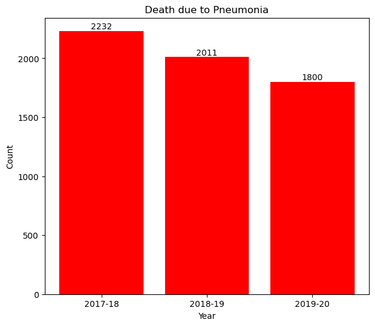

```python
import matplotlib.pyplot as plt

labels = ["2017-18", "2018-19", "2019-20"]
sizes = [2232,2011,1800]

# Horizontal bar chart with custom colors
plt.figure(figsize=(7, 6))
bars = plt.bar(labels, sizes,color='red')

# Title and labels
plt.title('Death due to Pneumonia')
plt.xlabel('Year')
plt.ylabel('Count')

# Display the values on top of each bar
for i, bar in enumerate(bars):
    plt.text(bar.get_x() + bar.get_width() / 2, bar.get_height(),
             sizes[i], ha='center', va='bottom')

# Display the chart
plt.show()
```

### Inference:

-This graph gives the number of infant death caused due to Pneumonia across all districts of Karnataka.

-In 2017-18, the death due to pneumonia was recorded the highest. And death rate due to pneumonia is decreasing gradually year to year.

### %death due to Pneumonia Division-wise

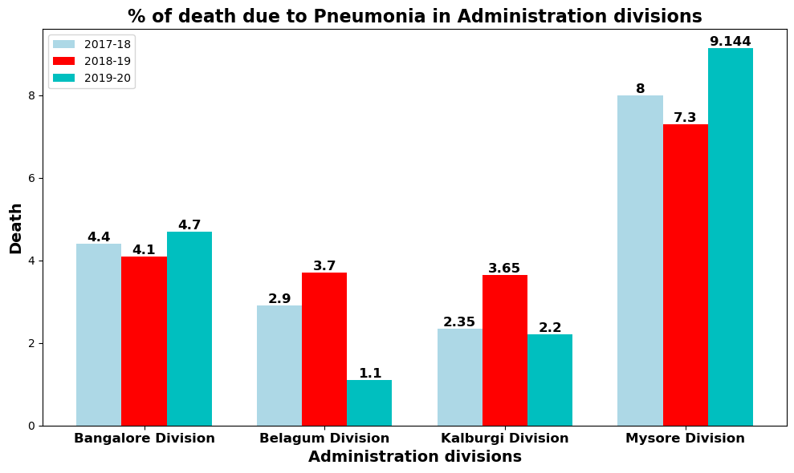

```python
import matplotlib.pyplot as plt

labels = ["Bangalore Division", "Belagum Division", "Kalburgi Division", "Mysore Division"]
year_1 = [4.4,2.9,2.35,8]
year_2 = [4.1,3.7,3.65,7.3]  # Replace these values with data for the second year
year_3 = [4.7,1.1,2.2,9.144] #Replace these values with data for the third year


bar_width = 0.25  # Width of each bar
bar_positions_1 = list(range(len(labels)))
bar_positions_2 = [pos + bar_width for pos in bar_positions_1]
bar_positions_3 = [pos + bar_width * 2 for pos in bar_positions_1]

# Horizontal bar chart with custom colors
plt.figure(figsize=(10, 6))  # Increase the figure size to make the text more visible
bars1 = plt.bar(bar_positions_1, year_1, width=bar_width, color="lightblue", label='2017-18')
bars2 = plt.bar(bar_positions_2, year_2, width=bar_width, color="red", label='2018-19')
bars3 = plt.bar(bar_positions_3, year_3, width=bar_width, color="c", label='2019-20')

# Title and labels with increased font size and bold text
plt.title('% of death due to Pneumonia in Administration divisions', fontsize=16, fontweight='bold')
plt.xlabel('Administration divisions', fontsize=14, fontweight='bold')
plt.ylabel('Death', fontsize=14, fontweight='bold')

# Display the values on top of each bar for year 1
for i, bar in enumerate(bars1):
    plt.text(bar.get_x() + bar.get_width() / 2, bar.get_height(),
             year_1[i], ha='center', va='bottom', fontsize=12, fontweight='bold', color='black')

# Display the values on top of each bar for year 2
for i, bar in enumerate(bars2):
    plt.text(bar.get_x() + bar.get_width() / 2, bar.get_height(),
             year_2[i], ha='center', va='bottom', fontsize=12, fontweight='bold', color='black')

# Display the values on top of each bar for year 3
for i, bar in enumerate(bars3):
    plt.text(bar.get_x() + bar.get_width() / 2, bar.get_height(),
             year_3[i], ha='center', va='bottom', fontsize=12, fontweight='bold', color='black')

# Set the x-axis ticks and labels
plt.xticks([pos + bar_width for pos in bar_positions_1], labels, fontsize=12, fontweight='bold')

# Add a legend
plt.legend()

# Display the chart
plt.tight_layout()
plt.show()
```

## Q18.What is the % of Death caused due to Pneumonia District-wise?

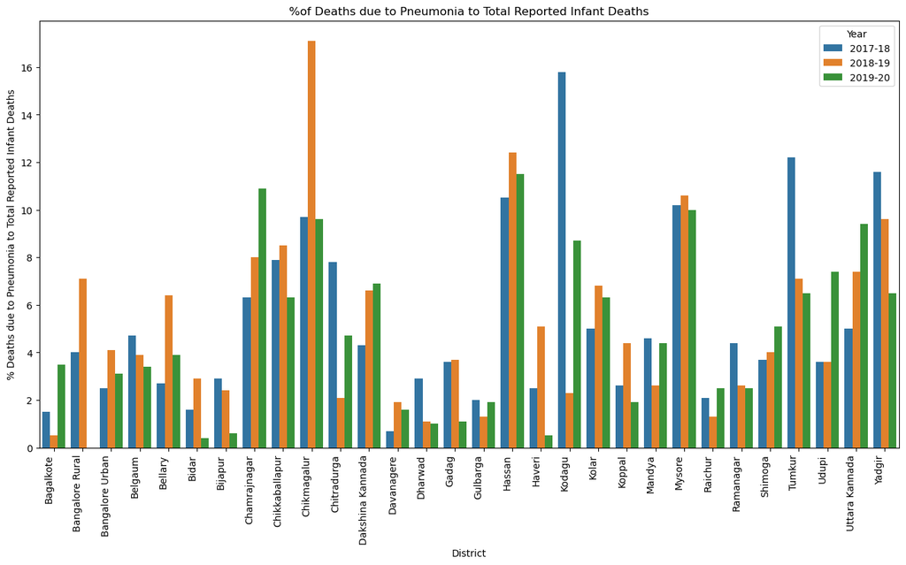

```python
fig, ax=plt.subplots(figsize=(16,8))
sns.barplot(data=names, x="District", y="% Deaths due to Pneumonia to Total Reported Infant Deaths", hue = 'Year',ax=ax)
ax.set_xticklabels(ax.get_xticklabels(),rotation=90,horizontalalignment='right')
plt.title("%of Deaths due to Pneumonia to Total Reported Infant Deaths")
plt.show()
```

### Inference:

-In 2017-18, Kodagu has recorded highest %of infant death due to Pneumonia and Davangere the least.

-In 2018-19, Chikamagalur has recorded highest %of infant death due to Pneumonia and Bagalkote the least.

## Q19.What is the number of recovered infants from Pneumonia?

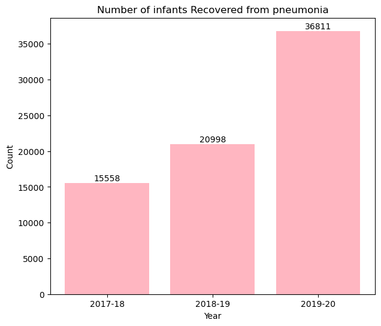

```python
import matplotlib.pyplot as plt

labels = ["2017-18", "2018-19", "2019-20"]
sizes = [15558,20998,36811]

# Horizontal bar chart with custom colors
plt.figure(figsize=(7, 6))
bars = plt.bar(labels, sizes,color='lightpink')

# Title and labels
plt.title('Number of infants Recovered from pneumonia')
plt.xlabel('Year')
plt.ylabel('Count')

# Display the values on top of each bar
for i, bar in enumerate(bars):
    plt.text(bar.get_x() + bar.get_width() / 2, bar.get_height(),
             sizes[i], ha='center', va='bottom')

# Display the chart
plt.show()
```

### Inference:

-As compared to 2017-18 and 2018-19 number of infants recovered from Pneumonia are more because number of infants affected in 2019-20 are more and death occur due to Pneumonia Is also less.

## Q20.What is the number of Death caused due to Fever?

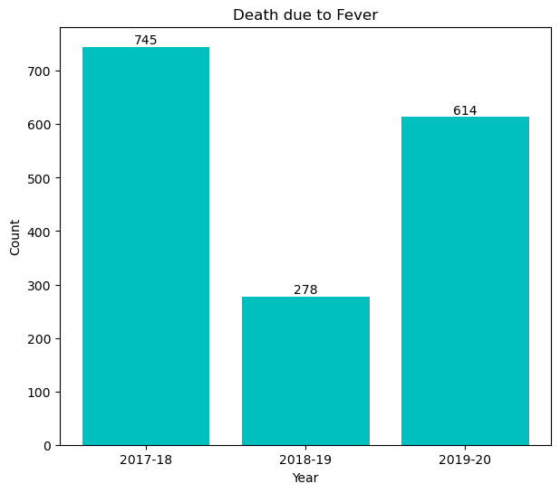

```python
import matplotlib.pyplot as plt

labels = ["2017-18", "2018-19", "2019-20"]
sizes = [745,278,614]

# Horizontal bar chart with custom colors
plt.figure(figsize=(7, 6))
bars = plt.bar(labels, sizes,color='c')

# Title and labels
plt.title('Death due to Fever')
plt.xlabel('Year')
plt.ylabel('Count')

# Display the values on top of each bar
for i, bar in enumerate(bars):
    plt.text(bar.get_x() + bar.get_width() / 2, bar.get_height(),
             sizes[i], ha='center', va='bottom')

# Display the chart
plt.show()
```

### Inference:

-This graph gives the number of infant death caused due to Fever across all districts of Karnataka.

-It depicts that the number of infants death due to fever has been varying year to year.

### %death due to Fever Division-wise

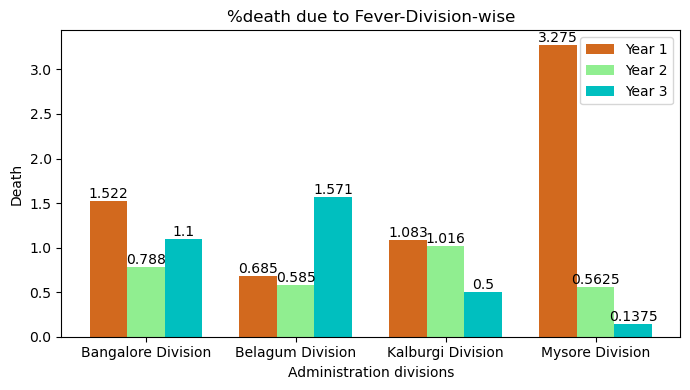

```python
import matplotlib.pyplot as plt

labels = ["Bangalore Division", "Belagum Division", "Kalburgi Division", "Mysore Division"]
year_1 = [1.522,0.685,1.083,3.275]
year_2 = [0.788,0.585,1.016,0.5625]  # Replace these values with data for the second year
year_3 = [1.1,1.571,0.5,0.1375] #Replace these values with data for the third year

bar_width = 0.25  # Width of each bar
bar_positions_1 = list(range(len(labels)))
bar_positions_2 = [pos + bar_width for pos in bar_positions_1]
bar_positions_3 = [pos + bar_width * 2 for pos in bar_positions_1]

# Horizontal bar chart with custom colors
plt.figure(figsize=(7, 4))
bars1 = plt.bar(bar_positions_1, year_1, width=bar_width, color="chocolate", label='Year 1')
bars2 = plt.bar(bar_positions_2, year_2, width=bar_width, color="lightgreen", label='Year 2')
bars3 = plt.bar(bar_positions_3, year_3, width=bar_width, color="c", label='Year 3')

# Title and labels
plt.title('%death due to Fever-Division-wise')
plt.xlabel('Administration divisions')
plt.ylabel('Death')

# Display the values on top of each bar for year 1
for i, bar in enumerate(bars1):
    plt.text(bar.get_x() + bar.get_width() / 2, bar.get_height(),
             year_1[i], ha='center', va='bottom')

# Display the values on top of each bar for year 2
for i, bar in enumerate(bars2):
    plt.text(bar.get_x() + bar.get_width() / 2, bar.get_height(),
             year_2[i], ha='center', va='bottom')

# Display the values on top of each bar for year 3
for i, bar in enumerate(bars3):
    plt.text(bar.get_x() + bar.get_width() / 2, bar.get_height(),
             year_3[i], ha='center', va='bottom')

# Set the x-axis ticks and labels
plt.xticks([pos + bar_width for pos in bar_positions_1], labels)

# Add a legend
plt.legend()

# Display the chart
plt.tight_layout()
plt.show()
```

## Q21.What is the % of Death caused due to Fever District-wise?

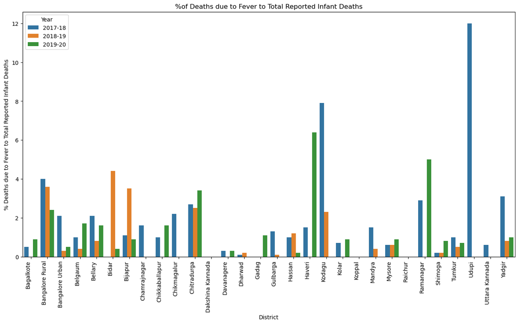

```python
fig, ax=plt.subplots(figsize=(16,8))
sns.barplot(data=names, x="District", y="% Deaths due to Fever to Total Reported Infant Deaths", hue = 'Year',ax=ax)
ax.set_xticklabels(ax.get_xticklabels(),rotation=90,horizontalalignment='right')
plt.title("%of Deaths due to Fever to Total Reported Infant Deaths")
plt.show()
```

### Inference:

-In 2017-18, Udupi has recorded highest %of infant death due to fever and Koppal, Dakshina Kannada, Gadag, Raichur the least.

-In 2018-19, Bidar has recorded highest %of infant death due to fever and Bagalkote, Chamrajnagar, Dakshina Kannada, Davangere, Gadag, Haveri,Kolar, Koppal, Raichur,Udupi, Uttara Kannada the least.

-In 2019-20, Haveri has recorded highest %of infant death due to fever and Chamrajnagar, Dakshina Kannada, Koppal, Raichur, Udupi, Uttar Kannada the least.

## Q22.What is the total number of Infants affected due to Measles?

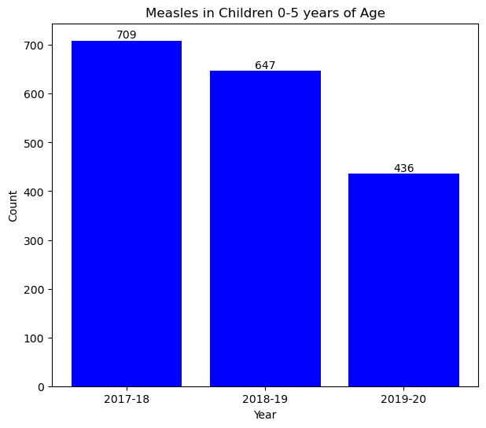

```python
import matplotlib.pyplot as plt

labels = ["2017-18", "2018-19", "2019-20"]
sizes = [709,647,436]

# Horizontal bar chart with custom colors
plt.figure(figsize=(7, 6))
bars = plt.bar(labels, sizes,color='b')

# Title and labels
plt.title('Measles in Children 0-5 years of Age')
plt.xlabel('Year')
plt.ylabel('Count')

# Display the values on top of each bar
for i, bar in enumerate(bars):
    plt.text(bar.get_x() + bar.get_width() / 2, bar.get_height(),
             sizes[i], ha='center', va='bottom')

# Display the chart
plt.show()
```

### Inference:

-As compared to 2017-18 and 2018-19 number of infants affected from Measles are less.

Reason:

-Direct contact with person having measles.

-Improper sanitation and hygiene.

## Q23.How many infants have received Measles Vaccination?

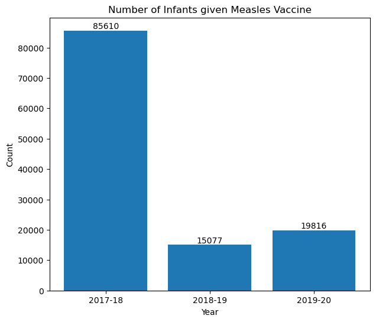

```python
import matplotlib.pyplot as plt

labels = ["2017-18", "2018-19", "2019-20"]
sizes = [85610,15077,19816]

# Horizontal bar chart with custom colors
plt.figure(figsize=(7, 6))
bars = plt.bar(labels, sizes)

# Title and labels
plt.title('Number of Infants given Measles Vaccine')
plt.xlabel('Year')
plt.ylabel('Count')

# Display the values on top of each bar
for i, bar in enumerate(bars):
    plt.text(bar.get_x() + bar.get_width() / 2, bar.get_height(),
             sizes[i], ha='center', va='bottom')

# Display the chart
plt.show()
```

### Inference:

-In 2017-18 around 85610 infants received Measles Rubella Vaccination.

-In 2018-19 around 15077 infants received Measles Rubella Vaccination.

-In 2019-20 around 19816 infants received Measles Rubella Vaccination.

## Q24.What is the number of Death caused due to Measles?

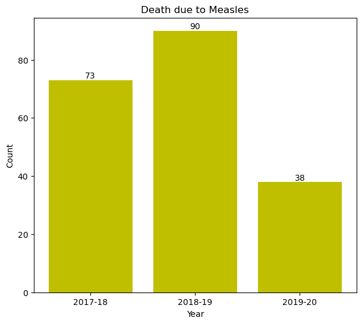

```python
import matplotlib.pyplot as plt

labels = ["2017-18", "2018-19", "2019-20"]
sizes = [73,90,38]

# Horizontal bar chart with custom colors
plt.figure(figsize=(7, 6))
bars = plt.bar(labels, sizes,color='y')

# Title and labels
plt.title('Death due to Measles')
plt.xlabel('Year')
plt.ylabel('Count')

# Display the values on top of each bar
for i, bar in enumerate(bars):
    plt.text(bar.get_x() + bar.get_width() / 2, bar.get_height(),
             sizes[i], ha='center', va='bottom')

# Display the chart
plt.show()
```

### Inference:

-This graph gives the number of infant death caused due to Measles across all districts of Karnataka.

Reason:

-Undiagnosed Measles can lead to Pneumonia which can result in death.

## Q25.What is the number of infants recovered from Measles?

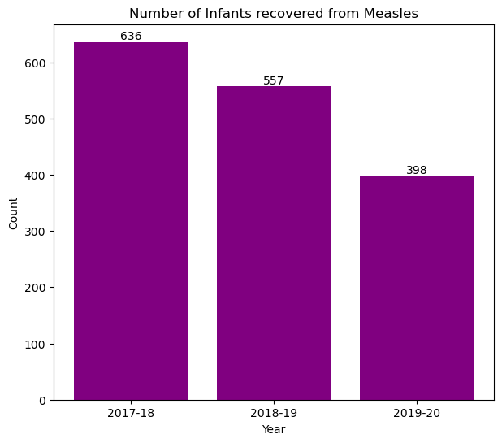

```python
import matplotlib.pyplot as plt

labels = ["2017-18", "2018-19", "2019-20"]
sizes = [636,557,398]

# Horizontal bar chart with custom colors
plt.figure(figsize=(7, 6))
bars = plt.bar(labels, sizes,color='purple')

# Title and labels
plt.title('Number of Infants recovered from Measles')
plt.xlabel('Year')
plt.ylabel('Count')

# Display the values on top of each bar
for i, bar in enumerate(bars):
    plt.text(bar.get_x() + bar.get_width() / 2, bar.get_height(),
             sizes[i], ha='center', va='bottom')

# Display the chart
plt.show()
```